# Brief introduction on the problem

The problem faced by great banks is "Should I rely credit(loan money) to this person?". Most of these problems come from the perennial need to build a house or to buy it from another person. Then banks databases can be a font of information to get the approvation or not. Particularly, people have biased opinion on which aspects are important to make a decision, but to be more assertive it's necessary to take a look on data.

Dataset found at https://www.kaggle.com/datasets/devzohaib/eligibility-prediction-for-loan

| nº | Variable | Description |
| --- | --- | --- |
| 1 | Loan_ID | Unique Loan ID |
| 2 | Gender | Male/ Female |
| 3 | Married | Applicant married (Y/N) |
| 4 | Dependents | Number of dependents |
| 5 | Education | Applicant Education (Graduate/ Under Graduate) |
| 6 | Self_Employed | Self employed (Y/N) |
| 7 | ApplicantIncome | Applicant income |
| 8 | CoapplicantIncome | Coapplicant income |
| 9 | LoanAmount | Loan amount in thousands |
| 10 | Loan_Amount_Term | Term of loan in months |
| 11 | Credit_History | Credit history meets guidelines |
| 12 | Property_Area | Urban/ Semi Urban/ Rural |
| 13 | Loan_Status | (Target) Loan approved (Y/N) |

# Importing utils libraries

```python
#!pip3 install pandas
```

```python
#!pip3 install seaborn
```

```python
#!pip3 install scikit-learn
```

```python
#!pip3 install mlxtend
```

```python
import os
import pandas as pd
import numpy as np
import seaborn as sns
import matplotlib.pyplot as plt

from sklearn.ensemble import ExtraTreesClassifier
```

# Reading data in csv

```python
df = pd.read_csv("loan.csv", sep=",", header=[0], encoding="latin")
```

# Randomic understading

```python
print(df.columns)
```

```
Index(['Loan_ID', 'Gender', 'Married', 'Dependents', 'Education',
       'Self_Employed', 'ApplicantIncome', 'CoapplicantIncome', 'LoanAmount',
       'Loan_Amount_Term', 'Credit_History', 'Property_Area', 'Loan_Status'],
      dtype='object')
```

```python
df.info()
```

```
<class 'pandas.core.frame.DataFrame'>
RangeIndex: 614 entries, 0 to 613
Data columns (total 13 columns):
 #   Column             Non-Null Count  Dtype
---  ------             --------------  -----
 0   Loan_ID            614 non-null    object
 1   Gender             601 non-null    object
 2   Married            611 non-null    object
 3   Dependents         599 non-null    object
 4   Education          614 non-null    object
 5   Self_Employed      582 non-null    object
 6   ApplicantIncome    614 non-null    int64
 7   CoapplicantIncome  614 non-null    float64
 8   LoanAmount         592 non-null    float64
 9   Loan_Amount_Term   600 non-null    float64
 10  Credit_History     564 non-null    float64
 11  Property_Area      614 non-null    object
 12  Loan_Status        614 non-null    object
dtypes: float64(4), int64(1), object(8)
memory usage: 62.5+ KB
```

```python
df.head()
```

|  | Loan_ID | Gender | Married | Dependents | Education | Self_Employed | ApplicantIncome | CoapplicantIncome | LoanAmount | Loan_Amount_Term | Credit_History | Property_Area | Loan_Status |
| --- | --- | --- | --- | --- | --- | --- | --- | --- | --- | --- | --- | --- | --- |
| 0 | LP001002 | Male | No | 0 | Graduate | No | 5849 | 0.0 | NaN | 360.0 | 1.0 | Urban | Y |
| 1 | LP001003 | Male | Yes | 1 | Graduate | No | 4583 | 1508.0 | 128.0 | 360.0 | 1.0 | Rural | N |
| 2 | LP001005 | Male | Yes | 0 | Graduate | Yes | 3000 | 0.0 | 66.0 | 360.0 | 1.0 | Urban | Y |
| 3 | LP001006 | Male | Yes | 0 | Not Graduate | No | 2583 | 2358.0 | 120.0 | 360.0 | 1.0 | Urban | Y |
| 4 | LP001008 | Male | No | 0 | Graduate | No | 6000 | 0.0 | 141.0 | 360.0 | 1.0 | Urban | Y |

```python
df.tail()
```

|  | Loan_ID | Gender | Married | Dependents | Education | Self_Employed | ApplicantIncome | CoapplicantIncome | LoanAmount | Loan_Amount_Term | Credit_History | Property_Area | Loan_Status |
| --- | --- | --- | --- | --- | --- | --- | --- | --- | --- | --- | --- | --- | --- |
| 609 | LP002978 | Female | No | 0 | Graduate | No | 2900 | 0.0 | 71.0 | 360.0 | 1.0 | Rural | Y |
| 610 | LP002979 | Male | Yes | 3+ | Graduate | No | 4106 | 0.0 | 40.0 | 180.0 | 1.0 | Rural | Y |
| 611 | LP002983 | Male | Yes | 1 | Graduate | No | 8072 | 240.0 | 253.0 | 360.0 | 1.0 | Urban | Y |
| 612 | LP002984 | Male | Yes | 2 | Graduate | No | 7583 | 0.0 | 187.0 | 360.0 | 1.0 | Urban | Y |
| 613 | LP002990 | Female | No | 0 | Graduate | Yes | 4583 | 0.0 | 133.0 | 360.0 | 0.0 | Semiurban | N |

```python
df.dtypes
```

```
Loan_ID               object
Gender                object
Married               object
Dependents            object
Education             object
Self_Employed         object
ApplicantIncome        int64
CoapplicantIncome    float64
LoanAmount           float64
Loan_Amount_Term     float64
Credit_History       float64
Property_Area         object
Loan_Status           object
dtype: object
```

# No_cleaned data visualization

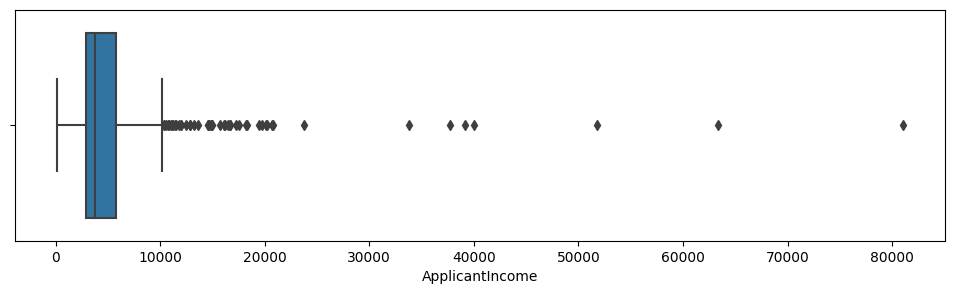

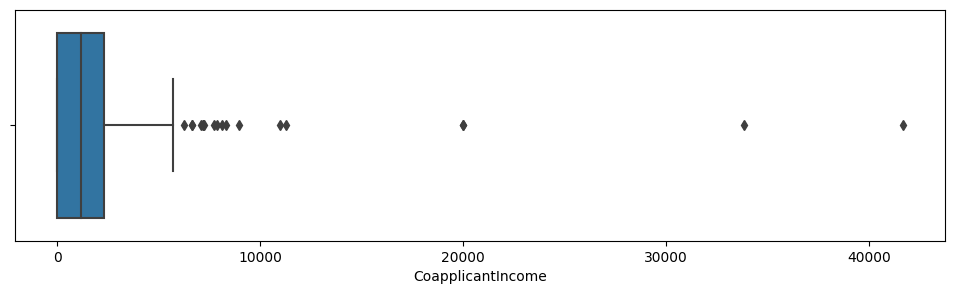

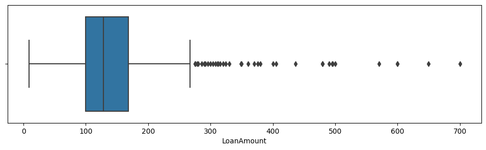

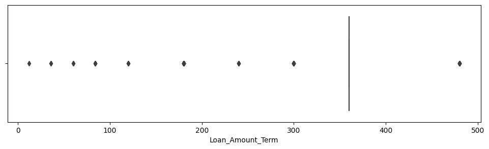

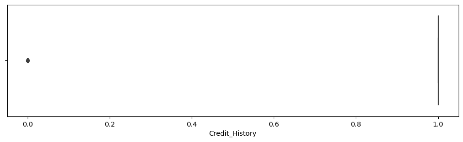

```python
plt.rcParams['figure.figsize'] = [12, 3]

numeric_cols = [column for column in df.columns if df[column].dtype != "object"]

for column in numeric_cols:
    plt.figure()
    sns.boxplot(x=df[column])
```

# Check and handling NaN values in dataframe

```python
df.isnull().sum()
```

```
Loan_ID               0
Gender               13
Married               3
Dependents           15
Education             0
Self_Employed        32
ApplicantIncome       0
CoapplicantIncome     0
LoanAmount           22
Loan_Amount_Term     14
Credit_History       50
Property_Area         0
Loan_Status           0
dtype: int64
```

### Here we are trying to understand how are these missing values, so I check values in each column changing the snippet below

```python
nan_counter=0
for single_data in df['Credit_History']:
    #print(single_data)
    if single_data != 1. and single_data != 0.:
        nan_counter += 1
nan_counter
```

```
50
```

After execute the snippet above we could find out that the missing values were all nan. Although we have a little dataset, it's necessary to remove all nan to train the models.

```python
cleaned_df =  df.dropna(axis=0)
cleaned_df.isnull().sum()
```

```
Loan_ID              0
Gender               0
Married              0
Dependents           0
Education            0
Self_Employed        0
ApplicantIncome      0
CoapplicantIncome    0
LoanAmount           0
Loan_Amount_Term     0
Credit_History       0
Property_Area        0
Loan_Status          0
dtype: int64
```

```python
cleaned_df.info()
```

```
<class 'pandas.core.frame.DataFrame'>
Int64Index: 480 entries, 1 to 613
Data columns (total 13 columns):
 #   Column             Non-Null Count  Dtype
---  ------             --------------  -----
 0   Loan_ID            480 non-null    object
 1   Gender             480 non-null    object
 2   Married            480 non-null    object
 3   Dependents         480 non-null    object
 4   Education          480 non-null    object
 5   Self_Employed      480 non-null    object
 6   ApplicantIncome    480 non-null    int64
 7   CoapplicantIncome  480 non-null    float64
 8   LoanAmount         480 non-null    float64
 9   Loan_Amount_Term   480 non-null    float64
 10  Credit_History     480 non-null    float64
 11  Property_Area      480 non-null    object
 12  Loan_Status        480 non-null    object
dtypes: float64(4), int64(1), object(8)
memory usage: 52.5+ KB
```

# Convert non_numerical data to numeric values

```python
all_numeric_df = cleaned_df.copy()
```

```python
for column in all_numeric_df.columns[1:6]:
    print(np.unique(all_numeric_df[column], return_counts=True))
```

```
(array(['Female', 'Male'], dtype=object), array([ 86, 394], dtype=int64))
(array(['No', 'Yes'], dtype=object), array([169, 311], dtype=int64))
(array(['0', '1', '2', '3+'], dtype=object), array([274,  80,  85,  41], dtype=int64))
(array(['Graduate', 'Not Graduate'], dtype=object), array([383,  97], dtype=int64))
(array(['No', 'Yes'], dtype=object), array([414,  66], dtype=int64))
```

```python
for column in all_numeric_df.columns[-3:]:
    print(np.unique(all_numeric_df[column], return_counts=True))
```

```
(array([0., 1.]), array([ 70, 410], dtype=int64))
(array(['Rural', 'Semiurban', 'Urban'], dtype=object), array([139, 191, 150], dtype=int64))
(array(['N', 'Y'], dtype=object), array([148, 332], dtype=int64))
```

```python
di = {
        'Gender': {
            "Male": 0,
            "Female": 1
        },
        'Married': {
            "No": 0,
            "Yes": 1
        },
        'Dependents': {
            "0": 0,
            "1": 1,
            "2": 2,
            "3+": 3
        },
        'Education': {
            "Graduate": 1,
            "Not Graduate": 0
        },
        'Self_Employed': {
            "Yes": 1,
            "No": 0
        },
        'Credit_History': {
            "0.": 0,
            "1.": 1
        },
        'Property_Area': {
            "Rural": 0,
            "Semiurban": 1,
            "Urban": 2
        },
        'Loan_Status': {
            "Y": 1,
            "N": 0
        }
    }
all_numeric_df.replace(di, inplace=True)
```

# Univariate Analysis

```python
all_numeric_df.describe()
```

|  | Gender | Married | Dependents | Education | Self_Employed | ApplicantIncome | CoapplicantIncome | LoanAmount | Loan_Amount_Term | Credit_History | Property_Area | Loan_Status |
| --- | --- | --- | --- | --- | --- | --- | --- | --- | --- | --- | --- | --- |
| count | 480.000000 | 480.000000 | 480.000000 | 480.000000 | 480.000000 | 480.000000 | 480.000000 | 480.000000 | 480.000000 | 480.000000 | 480.000000 | 480.000000 |
| mean | 0.179167 | 0.647917 | 0.777083 | 0.797917 | 0.137500 | 5364.231250 | 1581.093583 | 144.735417 | 342.050000 | 0.854167 | 1.022917 | 0.691667 |
| std | 0.383892 | 0.478118 | 1.020815 | 0.401973 | 0.344734 | 5668.251251 | 2617.692267 | 80.508164 | 65.212401 | 0.353307 | 0.776411 | 0.462287 |
| min | 0.000000 | 0.000000 | 0.000000 | 0.000000 | 0.000000 | 150.000000 | 0.000000 | 9.000000 | 36.000000 | 0.000000 | 0.000000 | 0.000000 |
| 25% | 0.000000 | 0.000000 | 0.000000 | 1.000000 | 0.000000 | 2898.750000 | 0.000000 | 100.000000 | 360.000000 | 1.000000 | 0.000000 | 0.000000 |
| 50% | 0.000000 | 1.000000 | 0.000000 | 1.000000 | 0.000000 | 3859.000000 | 1084.500000 | 128.000000 | 360.000000 | 1.000000 | 1.000000 | 1.000000 |
| 75% | 0.000000 | 1.000000 | 2.000000 | 1.000000 | 0.000000 | 5852.500000 | 2253.250000 | 170.000000 | 360.000000 | 1.000000 | 2.000000 | 1.000000 |
| max | 1.000000 | 1.000000 | 3.000000 | 1.000000 | 1.000000 | 81000.000000 | 33837.000000 | 600.000000 | 480.000000 | 1.000000 | 2.000000 | 1.000000 |

# Analyzing the curve shape of data distribution

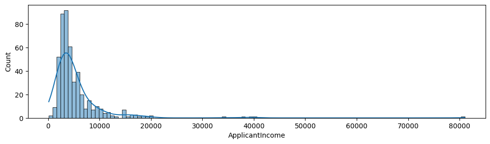

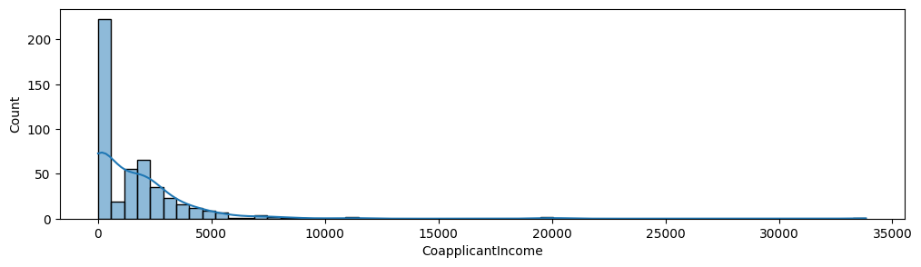

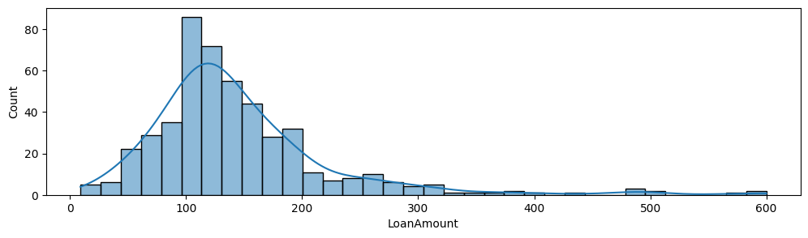

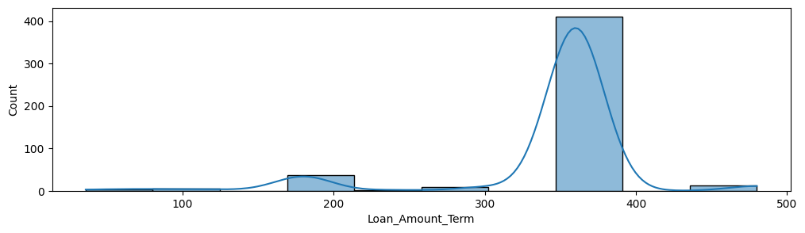

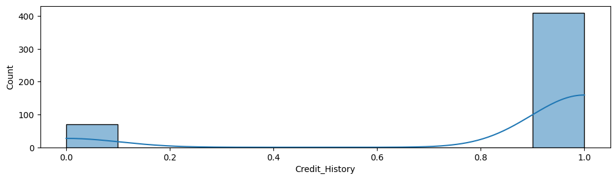

```python
for column in all_numeric_df.columns[6:11]:
    plt.figure()
    sns.histplot(all_numeric_df[column], kde=True)
```

# Taking a look on outliers in numerical original columns

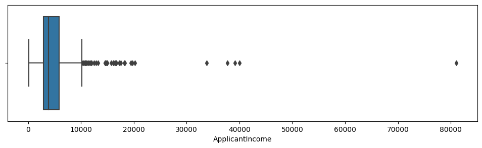

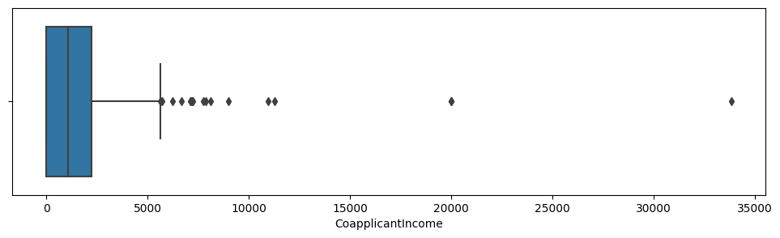

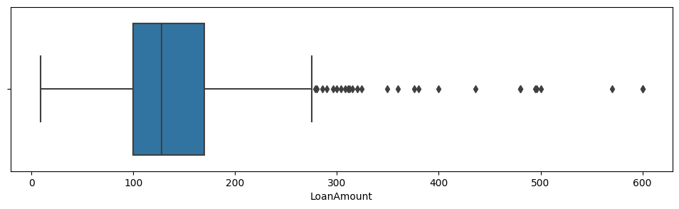

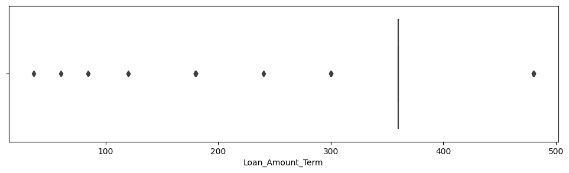

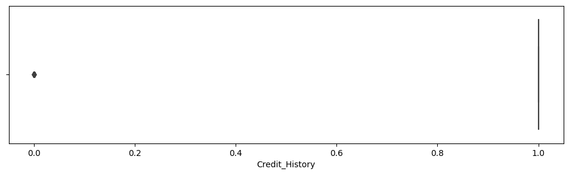

```python
for column in all_numeric_df.columns[6:11]:
    plt.figure()
    sns.boxplot(x=all_numeric_df[column])
```

In fact of the little amount of data and the context problem, there will be a problem of bias if I had removed the outliers.

# Bivariate Analysis

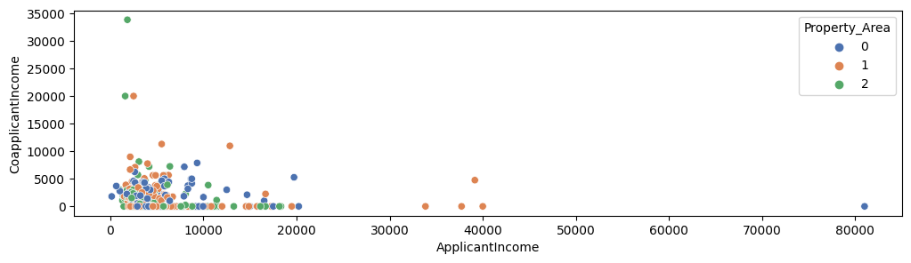

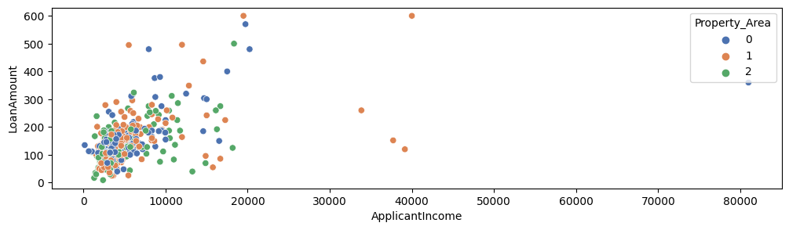

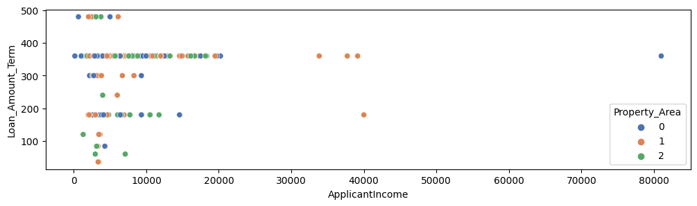

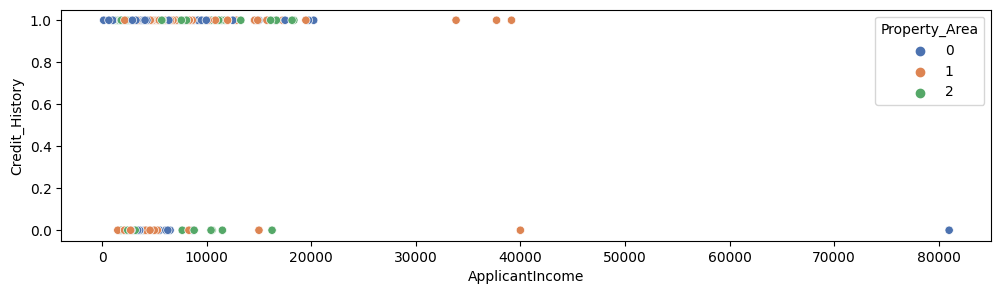

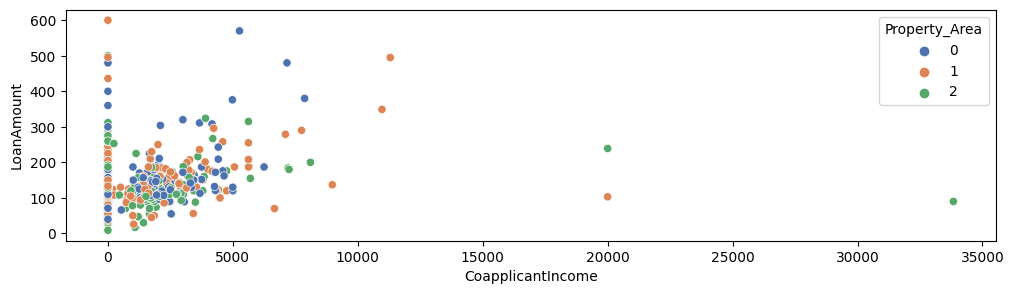

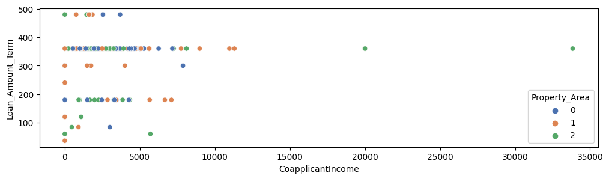

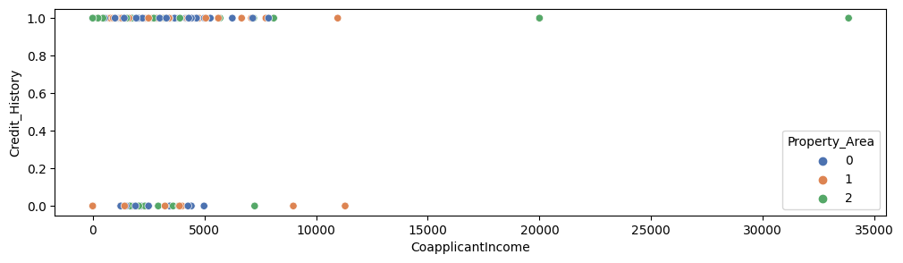

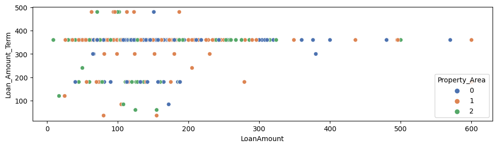

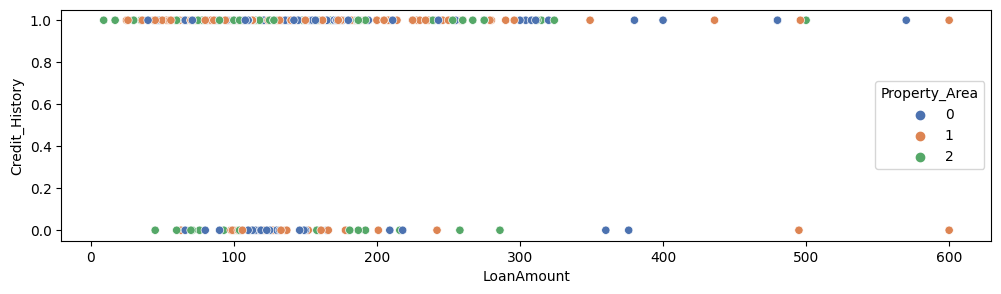

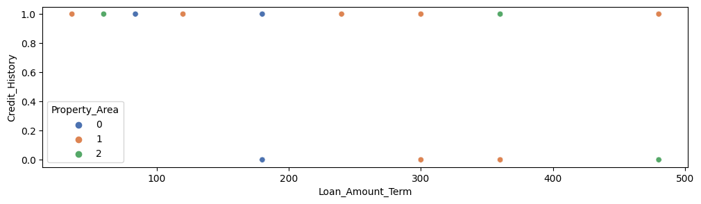

```python
numeric_cols = all_numeric_df.columns[6:12]

for i in range(len(numeric_cols)-1):
    for j in range(i+1, len(numeric_cols)-1):
        plt.figure()
        sns.scatterplot(data=all_numeric_df, x=numeric_cols[i], y=numeric_cols[j], hue="Property_Area", palette="deep")
```

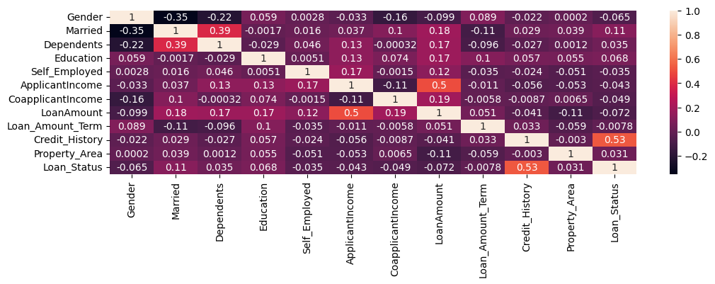

```python
sns.heatmap(data=all_numeric_df.corr(numeric_only=True), annot=True)
```

# Feature selection

```python
all_numeric_df.columns
```

```
Index(['Loan_ID', 'Gender', 'Married', 'Dependents', 'Education',
       'Self_Employed', 'ApplicantIncome', 'CoapplicantIncome', 'LoanAmount',
       'Loan_Amount_Term', 'Credit_History', 'Property_Area', 'Loan_Status'],
      dtype='object')
```

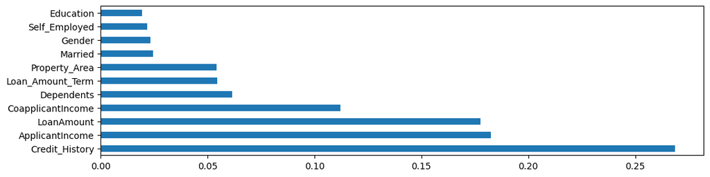

```python
X = all_numeric_df.iloc[:,1:12]  #independent columns
y = all_numeric_df.iloc[:,-1]    #target column


model = ExtraTreesClassifier()
model.fit(X,y)
#print(model.feature_importances_) #use inbuilt class feature_importances of tree based classifiers
#plot graph of feature importances for better visualization
feat_importances = pd.Series(model.feature_importances_, index=X.columns)
feat_importances.nlargest(12).plot(kind='barh')
plt.show()
```

This snippet show us that Credit_History variable is more relevant when we use ExtraTrees as classifier and makes me infer about relevant features in other models.

# Apply in regression models

```python
from sklearn.model_selection import train_test_split


X_train, X_test, y_train, y_test = train_test_split(all_numeric_df.iloc[:, :-1], all_numeric_df.iloc[:, -1], test_size=0.33, random_state=42)
```

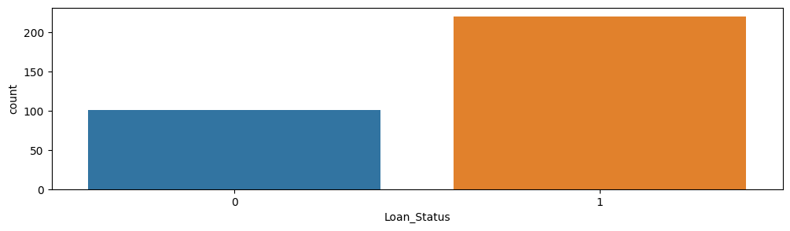

```python
sns.countplot(x=y_train)
```

```python
from sklearn.linear_model import LinearRegression


reg = LinearRegression().fit(X_train.iloc[:, 1:], y_train)

test_result = np.around(reg.predict(X_test.iloc[:, 1:]))
np.unique(test_result, return_counts=True)
```

[output not shown]

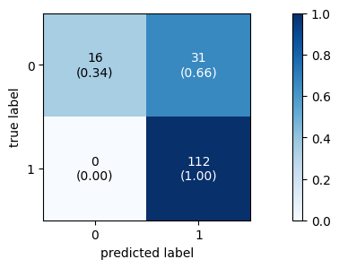

```python
from sklearn.metrics import confusion_matrix
from mlxtend.plotting import plot_confusion_matrix


cfm = confusion_matrix(y_test.array, test_result)
fig, ax = plot_confusion_matrix(conf_mat=cfm,
                                show_absolute=True,
                                show_normed=True,
                                colorbar=True)
plt.show()
```

This confusion matrix is a warning on imbalanced data because the model made an assumption mistake supposing the most of data was the majority class.

### Using resample technique to balance data

```python
from sklearn.utils import resample

df_majority = all_numeric_df[(all_numeric_df['Loan_Status']==1)]
df_minority = all_numeric_df[(all_numeric_df['Loan_Status']==0)]
# upsample minority class
df_minority_upsampled = resample(df_minority,
                                 replace=True,    # sample with replacement
                                 n_samples= 332, # to match majority class
                                 random_state=42)  # reproducible results
# Combine majority class with upsampled minority class
X = pd.concat([df_minority_upsampled, df_majority])
```

```python
y = X.iloc[:, -1]
X = X.iloc[:, :-1]
```

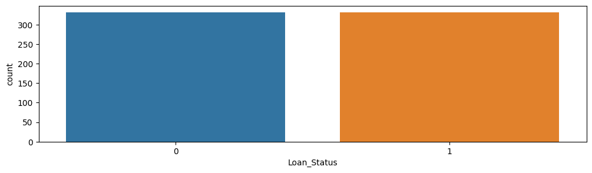

```python
sns.countplot(x=y)
```

```python
X_train, X_test, y_train, y_test = train_test_split(X, y, test_size=0.33, random_state=42)

reg = LinearRegression().fit(X_train.iloc[:, 1:], y_train)

test_result = np.around(reg.predict(X_test.iloc[:, 1:]))
np.unique(test_result, return_counts=True)
```

```
(array([0., 1.]), array([ 74, 146], dtype=int64))
```

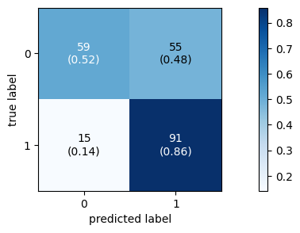

```python
cfm = confusion_matrix(y_test.array, test_result)
fig, ax = plot_confusion_matrix(conf_mat=cfm,
                                show_absolute=True,
                                show_normed=True,
                                colorbar=True)
plt.show()
```

We can see that there is a undesirable result (the chosen linear model is making mistakes about "Loan_Status= No" predictions). This can be explained because there is a little amount of data yet or the chosen model is too simple for make the predictions. So for complementing, let's experiment Random Forest Regressor.

```python
from sklearn.ensemble import RandomForestRegressor


reg = RandomForestRegressor(max_depth=2, random_state=0)
regr = reg.fit(X_train.iloc[:, 1:],y_train)
result = np.around(reg.predict(X_test.iloc[:, 1:]))
np.unique(result, return_counts=True)
```

```
(array([0., 1.]), array([ 52, 168], dtype=int64))
```

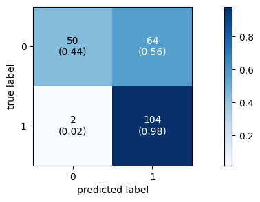

```python
cfm = confusion_matrix(y_test.array, result)
fig, ax = plot_confusion_matrix(conf_mat=cfm,
                                show_absolute=True,
                                show_normed=True,
                                colorbar=True)
plt.show()
```

# Commenting about results

In this work I made the common steps in general EDA: read the description, statistic description on each column, checking and handling missing values, univariate, bivariate and almost multivariate(dimensionality reduction wasn't a step I wanted handling with a little amount of data) analysis. After that I transformed categorical columns in numerical and passed it to fit prediction models. Unfortunately the results were better using the simplest method I knew and even so its confusion matrix seemed to indicate overfitting. In conclusion, it's very important to get more data and test other models to improve the quality of the process.